# Project Final

Charles Gerteis, Victoria Peryniak, Zihao Lin, Eugene Obah, Jordan Barkin

2022-12-05

### Data

The data set we are analyzing was collected by Reuters journalists in 2020 ([reuters.com](https://www.reuters.com/investigates/special-report/usa-jails-graphic/)). It contains information about all reported inmate deaths in the largest US jails from 2008 to 2019. The original data set contains information about 253 US jails, where each row corresponds to a jail. The number of total deaths for that jail is broken down into years, from 2008 to 2019. The death counts are further broken down into the amount of deaths caused by certain causes of death. The causes of death included were suicide, acute drug or alcohol related deaths, illness/natural death, homicides, and other causes.The average daily inmate population per year, from 2008-2019, is also included for each jail, as well as the jails’ medical provider(s) for each year. For the purposes of our analyses, we will be using the total deaths and average daily inmate populations for each year. The processed data set contains information about the average prison for each state. Each row corresponds to one state where the data is averaged between all jails observed and all years of observation in that state. Columns for total deaths, and deaths by each type (suicide, drug/alcohol, etc). For example, In Alabama there are 12 jails, so we took the means of the death statistics (total deaths, suicide, drug/alcohol, etc) in each jail from years 2008-2019, and then we take the total mean of the 12 jails, to collect our variable mean. For some jails, there are some years with missing death rate data. We compensate for this missing data by only taking the means of the years that are given. This could potentially affect our interpretation or results because we are taking smaller samples of those jails, and it has different proportions.

### Analysis

#### Comparing the States

[output not shown]

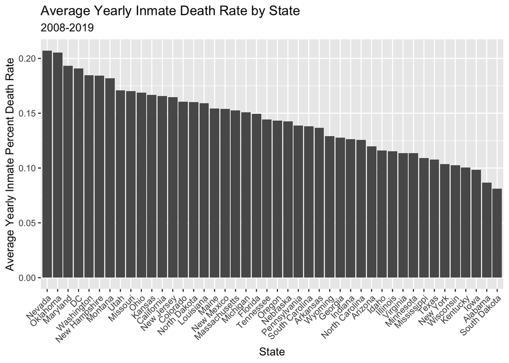

#### Correlation of Population and Death Rate

```
##
## Call:
## lm(formula = death_rate ~ avg_inmate_pop, data = state_summaries)
##
## Residuals:
##        Min         1Q     Median         3Q        Max
## -6.414e-04 -2.705e-04  5.900e-07  2.287e-04  6.227e-04
##
## Coefficients:
##                  Estimate Std. Error t value Pr(>|t|)
## (Intercept)     1.459e-03  9.193e-05  15.875   <2e-16 ***
## avg_inmate_pop -3.100e-08  1.009e-07  -0.307     0.76
## ---
## Signif. codes:  0 '***' 0.001 '**' 0.01 '*' 0.05 '.' 0.1 ' ' 1
##
## Residual standard error: 0.000323 on 42 degrees of freedom
## Multiple R-squared:  0.002243,   Adjusted R-squared:  -0.02151
## F-statistic: 0.09442 on 1 and 42 DF,  p-value: 0.7601
```

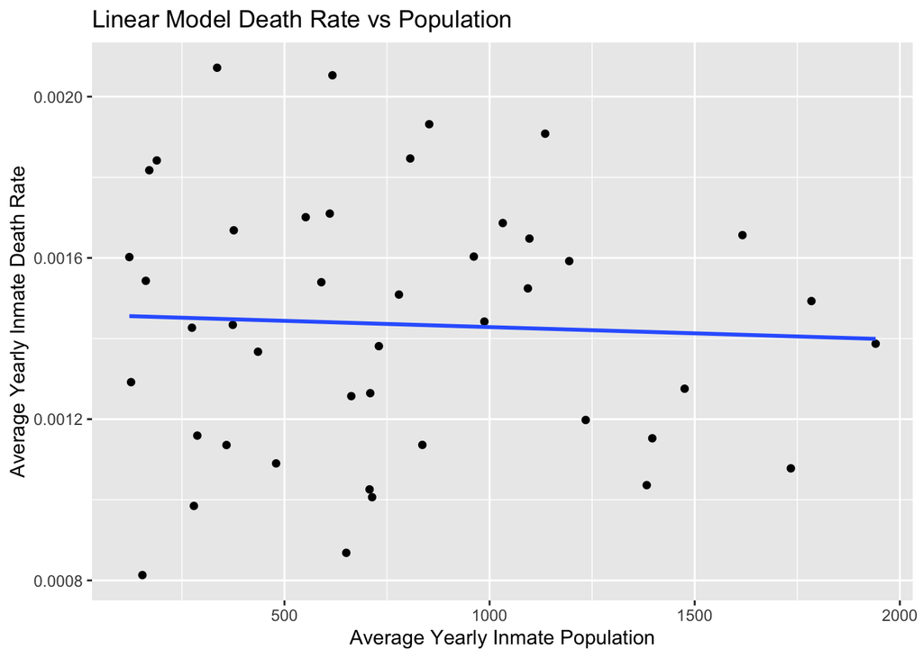

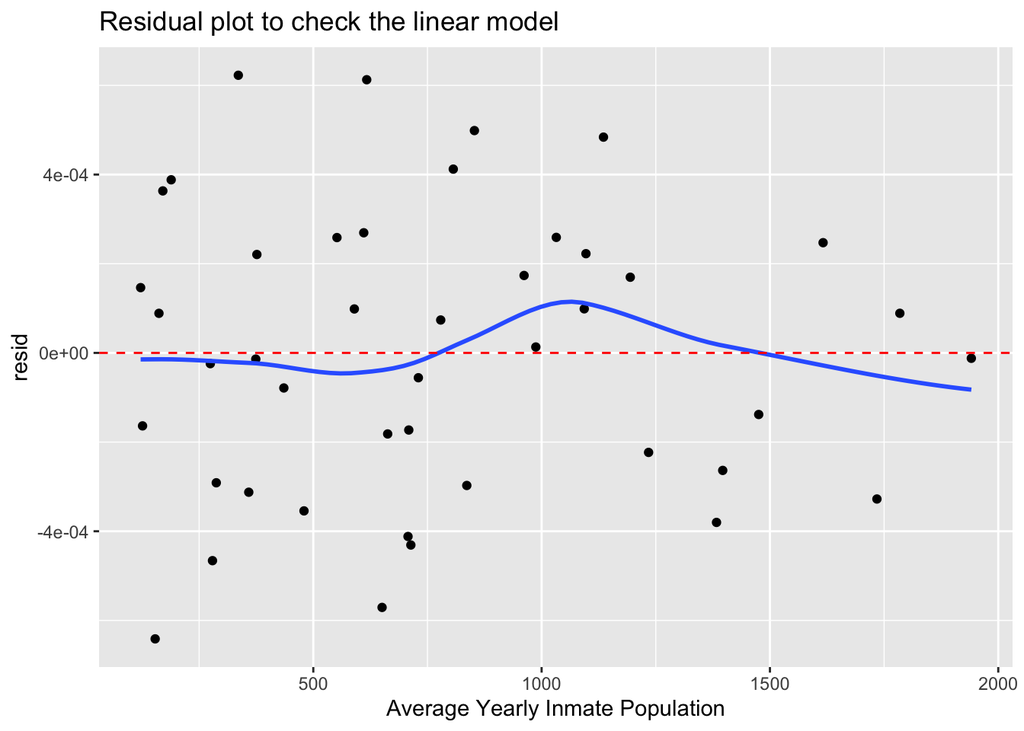

Although this linear model shows a slight negative correlation between inmate population and death rate, as well as having a good residual plot with consistent variance and mean of zero, the test to see if the slope is significantly different than zero was not able to reject the null (p = 0.7601, t-test, df = 42). So we are able to say that there is no clear evidence that death rate increases or decreases with an change in inmate population. This tells us that differences in death rate are not necessarily due to differences in inmate populations but are actually more likely due to how different states treat prisoners and the conditions they live in.

#### Hypothysis Test

$$X1∣p∼Binomial(707,p)$$

$$H_0: p = 0.010751 \\
H_a: p > 0.010751$$

```
## # A tibble: 1 × 6
##   statecode prison_deaths p_tilde      se z_score p_value
##   <chr>             <dbl>   <dbl>   <dbl>   <dbl>   <dbl>
## 1 WI                0.726 0.00383 0.00232   -2.99   0.999
```

We want to test if the average yearly death rate for Wisconsin prisons in this data set is greater than that of the general population of Wisconsin, which is 1,075.1 per 100,000 ([cdc.gov](https://www.cdc.gov/nchs/pressroom/states/wisconsin/wisconsin.htm)). Since our data is per capita and we need to do a test comparing proportions, we needed to scale down the state death rate by 100000, giving us a death rate of 0.010751. We were not able to reject the null hypothesis, the average yearly death rate for Wisconsin prisons in this data set was not significantly greater than the Wisconsin death rate (p = 0.99).

### Discussion

In regards to comparing Wisconsin inmate versus civilian deaths, the hypothesis test we conducted showed that there was no significant statistical information to suggest that Wisconsin inmate deaths occur more often than civilian deaths. A broader interpretation of this conclusion could be that Wisconsin jails aren’t mistreating their inmates, which could cause them to die more often than regular civilians. Other states with higher death rates would suggest that something about the jails is putting the inmates more at risk of death. Additionally, we found that Wisconsin had some of the lowest death rates among inmates among all states in the US. This could potentially explain why we don’t see noticeably higher deaths among Wisconsin inmates vs civilians, as the inmate deaths occur at a very low rate. A potential shortcoming of the analysis would be a lack of complete data for every jail. For whatever reason, our source didn’t track every jail for the same time frame. Some jails started being tracked earlier than others and some stopped being tracked before the last year of data collection. Another short-coming that has arisen from our analysis is that the death rate data for Wisconsin civilians was taken from 2020. The data set we used for the jails ends in 2019, so COVID-19 hadn’t yet had an impact on the jail data. The death rate for the Wisconsin jails would likely be slightly higher due to the prevalence of COVID in 2020. Regardless, the p value being 0.99 means that this short-coming probably won’t have much of an effect on the data. A potential future direction for additional work could involve working with the types of deaths found in the jails. The source we used for this analysis also included data about how the prisoners died, so that could be something to pivot towards. Our hypothesis test concluded that there wasn’t sufficient evidence to say that Wisconsin jails have a higher death rate than the general population. To find something statistically significant about Wisconsin jails, the next step would be to look at specific causes of deaths in the jails and see if there’s a certain type of death more prevalent in comparison to other states. Overall we have found that, in terms of overall death rate, Wisconsin jails are fairly safe not only compared to other US states, but also compared to Wisconsin’s overall death rate.